# CASE STUDY

This case study looks at three models. They are all discrete-time state-space models of the kind $$ \left\lbrace \begin{aligned} \boldsymbol x_{t+1} &= f_i(\boldsymbol x_t, \boldsymbol u_t, \boldsymbol \theta_i) + \boldsymbol w_t \,,\\ \boldsymbol z_t &= \textbf{H} \boldsymbol x_t\,,\\ \boldsymbol y_t &= \boldsymbol z_t + \boldsymbol v_t \,, \end{aligned} \right.$$ where $\boldsymbol x_t \sim \mathcal{N}(\boldsymbol \mu_t, \boldsymbol \Sigma_t)$ are the latent states at time $t$, $\boldsymbol u_t \sim \mathcal{N}(\boldsymbol u_t, \boldsymbol \Sigma_u)$ are the control inputs, $\boldsymbol \theta_i \sim \mathcal{N}(\hat{\boldsymbol \theta}_i, \boldsymbol \Sigma_{\theta,i})$ are the model parameters for model $i$, $\boldsymbol w_t \sim \mathcal{N}(\boldsymbol 0, \textbf{Q})$ is i.i.d. process noise, $\boldsymbol z_t$ are the measured states and $\boldsymbol v_t \sim \mathcal{N}(\boldsymbol 0, \textbf{R})$ is i.i.d. measurement noise.

### Set-up

We begin by importing some standard packages

```python
# Standard math package
import numpy as np
np.set_printoptions(4)

# Package for plotting results
import matplotlib.pyplot as plt
```

Next we have some flags that we can set as we wish

```python
# Number of time steps each experiment should last
num_time_steps = 50

# Number of initial experiments (before we begin optimal design of experiments)
num_init_exp = 3
```

We generate initial experimental data

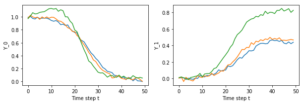

```python
from doepy.case_studies.discrete_time import nonlinear2
from doepy.models import CandidateWrapper
from doepy.models.discrete_time import dtModel

DM, Ms  = nonlinear2.get()
datagen = dtModel(CandidateWrapper(**DM.get_candidate_dict()))

# Generate experiments
U_data = DM.get_initial_experiments(num_init_exp, num_time_steps)
# Run experiments and collect measurements
Y_data = [ datagen.sample(None, U)[1] for U in U_data ]

# Time step sequence
T = np.arange(num_time_steps)

# Plot initial data
fig, axs = plt.subplots(1,2,figsize=(10,3))
for Y in Y_data:
    axs[0].plot(T, Y[:,0])
    axs[1].plot(T, Y[:,1])

axs[0].set_xlabel('Time step t')
axs[0].set_ylabel('Y_0')
axs[1].set_xlabel('Time step t')
axs[1].set_ylabel('Y_1')
plt.show()
```

### Surrogate models

For a detailed description of how to set up the surrogate models, see the model discrimination tutorial.

##### Initialisation

```python
from doepy.models.discrete_time import dtGPModel

dicts   = [ M.get_candidate_dict() for M in Ms ]
models  = [ dtGPModel(CandidateWrapper(**d)) for d in dicts ]
```

##### Parameter estimation

```python
from doepy.param_estim.state_space import least_squares

for i,model in enumerate(models):
    # Initial guess for model parameter values
    p_init = Ms[i].p0
    # Bounds on model parameter values
    p_bounds = Ms[i].p_bounds
    # Initial states
    X0 = [ model.x0 ] * len( U_data )
    # Parameter estimation
    model.p_mean = least_squares(model, p_inital_guess, p_bounds, X0, U_data, Y_data)['x']
```

##### Training

```python
for i,model in enumerate(models):
    p_sample_bounds = model.p_mean[:,None] * np.array([0.95, 1.05])
    model.train(p_bounds=p_sample_bounds)
```

##### Model parameter covariance

```python
from doepy.param_covar import state_space_laplace

for model in models:
    model.p_covar = state_space_laplace(model, U_data)
```

### Design of experiments for model discrimination

##### Objective function

The goal is to find the control sequence that maximises the divergence between the rival models' predictive distributions.

We choose the Jensen-Rényi divergence criterion $D_\mathrm{JR}$ (Olofsson et al., 2019, *Comp Chem Eng* 125:54-70) as our objective function. $$ \max_{u_1, \dots, u_T} \sum_t D_\mathrm{JR} [ \boldsymbol z_t^{(1)} \| \dots \| \boldsymbol z_t^{(M)} ] $$ where $\boldsymbol z_t^{(i)} \sim \mathcal{N}(\boldsymbol \mu_{z,t}^{(i)}, \boldsymbol \Sigma_{z,t}^{(i)})$ is model $i$'s prediction at time-step $t$.

```python
from doepy.model_discrimination.design_criteria import JR

divergence_criterion = JR()
```

##### Constraints

We have three different constraints (the same for all models):

- Path constraint $\boldsymbol z_t \in \mathcal{Z}$ for $t=1,\dots,T$.
- Control bounds $\boldsymbol u_t \in \mathcal{U}$ for $t=1,\dots,T$.
- Control change constraint $| u_{t+1,j} - u_{t,j} | \leq \Delta_{j}$ for all $t=1,\dots,T-1$ and $j=1,\dots,|\mathcal{U}|$.

```python
from doepy.constraints import ControlDeltaConstraint, ConstantMeanStateConstraint

# Path constraints
# --> Can currently only satisfy for predictive mean
z_const  = ConstantMeanStateConstraint(Ms[0].z_bounds)

# Control input bounds
u_bounds = Ms[0].u_bounds

# Control change constraint
u_const  = ControlDeltaConstraint(Ms[0].u_delta)
```

##### Optimisation

DoEpy has a class called ProblemInstance, which takes care of comuting the objective function and constraints (including their respective gradients with respect to the input control sequence) during the optimisation procedure.

```python
from doepy import ProblemInstance

PI = ProblemInstance(models, num_time_steps, divergence_criterion, u_bounds, u_const, z_const)
```

Now we're ready to run the optimisation procedure to find the optimal next experiment. DoEpy comes with a wrapper (essentially the Scipy wrapper with some tweaks to make optimisation more efficient and stable) for the SLSQP constrained optimisation algorithm written by Dieter Kraft.

We also use a LogCallback object so we can later analyse how the optimisation went.

```python
from doepy.optimize import slsqp
from doepy.optimize import LogCallback

U_initial_guess = U_data[0]
log   = LogCallback()
res   = slsqp(PI, U_initial_guess, log_callback=log)
U_opt = res['u']
print( res['message'] )
```

```
Optimization terminated successfully.
```

We can check the optimisation log to see how the values of the objective function and constraints changed with the number of iterations

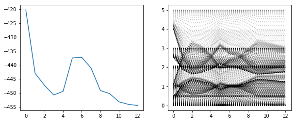

```python
fig,axs = plt.subplots(1,2,figsize=(10,4))

# Load log data
data = log.load()

N = np.arange(data['n'])  # Number of iterations
f = data['f']             # Objective function
c = np.vstack(data['c'])  # Constraints

# Plot
axs[0].plot(N,f)
axs[1].plot(N,c,'k:',alpha=0.1)
plt.show()
```

### Running the new experiment

We run the new experiment given by the optimised control sequence.

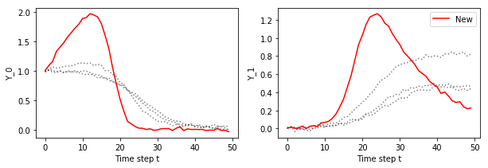

```python
# Run experiment and collect measurements
Y_new = datagen.sample(None, U_opt)[1]

# Plot initial data
fig, axs = plt.subplots(1,2,figsize=(10,3))
for Y in Y_data:
    # Old experiments
    axs[0].plot(T, Y[:,0], ':k', alpha=0.5)
    axs[1].plot(T, Y[:,1], ':k', alpha=0.5)
# New experiment
axs[0].plot(T, Y_new[:,0], 'r')
axs[1].plot(T, Y_new[:,1], 'r', label='New')

axs[0].set_xlabel('Time step t')
axs[0].set_ylabel('Y_0')
axs[1].set_xlabel('Time step t')
axs[1].set_ylabel('Y_1')
plt.legend()
plt.show()
```

### Model predictions

How well do the models predict the experimental data?

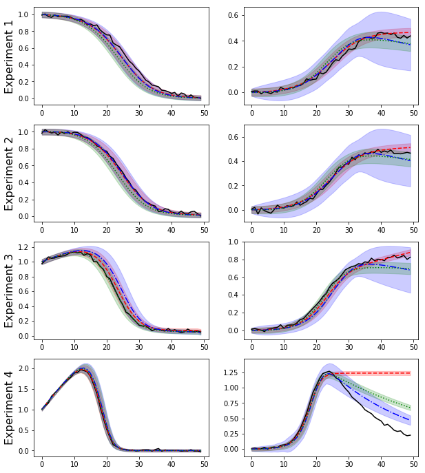

```python
num_exp = num_init_exp + 1

fig, axs = plt.subplots(num_exp, 2, figsize=(10, num_exp*3))
cols, ls = ['r', 'b', 'g'], ['--', '-.', ':']

num_models = 3   # Number of rival models
num_meas   = 2   # Number of measured states

# Combine experimental data
Y_data2 = Y_data + [Y_new,]
U_data2 = U_data + [U_opt,]

# For saving predictions
Y_pred   = [ ]
S_Y_pred = [ ]

for j in range(num_exp):
    axs[j][0].set_ylabel('Experiment %d'%(j+1), rotation=90, fontsize=16)
    axs[j][0].plot(T, Y_data2[j][:,0], 'k')
    axs[j][1].plot(T, Y_data2[j][:,1], 'k', label='Data')

    Y   = np.zeros(( num_models, num_time_steps, num_meas ))
    S_Y = np.zeros(( num_models, num_time_steps, num_meas, num_meas ))

    for i,model in enumerate(models):
        # Initial latent state mean and covariance
        x0   = model.x0
        S_x0 = model.x0_covar

       # Compute latent state predictions
        X, S_X = model.predict_x_dist(x0, S_x0, U_data2[j])

        # Translate latent state predictions to observed state predictions
        Y[i], S_Y[i] = model.predict_y_dist(X[:-1], S_X[:-1])

        for d in range(2):
            # Mean and two standard deviations
            y, s  = Y[i,:,d], 2*np.sqrt( S_Y[i,:,d,d] )
            axs[j][d].plot(T, y, ls[i]+cols[i], label='%s'%model.name)
            axs[j][d].fill_between(T, y+s, y-s, color=cols[i], alpha=0.2)

    # Save results
    Y_pred.append( Y )
    S_Y_pred.append( S_Y )

plt.show()
```

We see that the new experiment (Experiment 4) does indeed come with very different model predictions for the later time steps.

### Model discrimination

The proper thing to do after a new experiment has been run is to re-fit all model parameters. After that, model discrimination is performed. If there is still more than one model remaining, the design of experiments procedure is repeated.

Here we will just show how well the models perform for the model discrimination criteria outlined in the model discrimination tutorial, without re-fitting the model parameters.

```python
Y_all = np.vstack( Y_data2 )
Z_all = np.concatenate( Y_pred, axis=1 )
S_all = np.concatenate( S_Y_pred, axis=1 )
```

##### Marginal likelihood

```python
from doepy.model_discrimination import relative_likelihood

rel_lik = relative_likelihood(Y_all, Z_all, S_all)

# Print result
for rl, model in zip(rel_lik, models):
    print('%s: %f  (log10: %f)'%(model.name, rl, np.log10(rl)))
```

```
M1: 0.000000  (log10: -43.730478)
M2: 1.000000  (log10: 0.000000)
M3: 0.000000  (log10: -43.429448)
```

###### KL divergence

```python
from doepy.model_discrimination import symmetric_KL

kl_symmetric = symmetric_KL( Y_all, Z_all, S_all )

# Print result
for kl, model in zip(kl_symmetric, models):
    print('%s: %f'%(model.name, kl ))
```

```
M1: 51.560429
M2: 0.195209
M3: 6.721522
```

##### $\chi^2$ test

```python
from doepy.model_discrimination import chi2_adequacy_test

num_param = [ model.num_param for model in models ]
chi2_test = chi2_adequacy_test(Y_all, Z_all, S_all, num_param)

# Print result
for chi2, model in zip(chi2_test, models):
    print('%s: %f'%(model.name, chi2 ))
```

```
M1: 0.000000
M2: 0.000000
M3: 0.000000
```

We see that the marginal likelihood test and KL divergence test both think model M2 is significantly more likely to be the true model than models M1 and M3. However, the $\chi^2$ test deems all models inadequate.

###### Note

Before performing model discrimination given new experimental data, you should always re-tune the model parameters such that they incorporate information from the new experiment. Especially the $\chi^2$ test will assume that this has been done.